# Abundance Modeling

Andy

3/14/2022

# Models of Mosquito Abundance

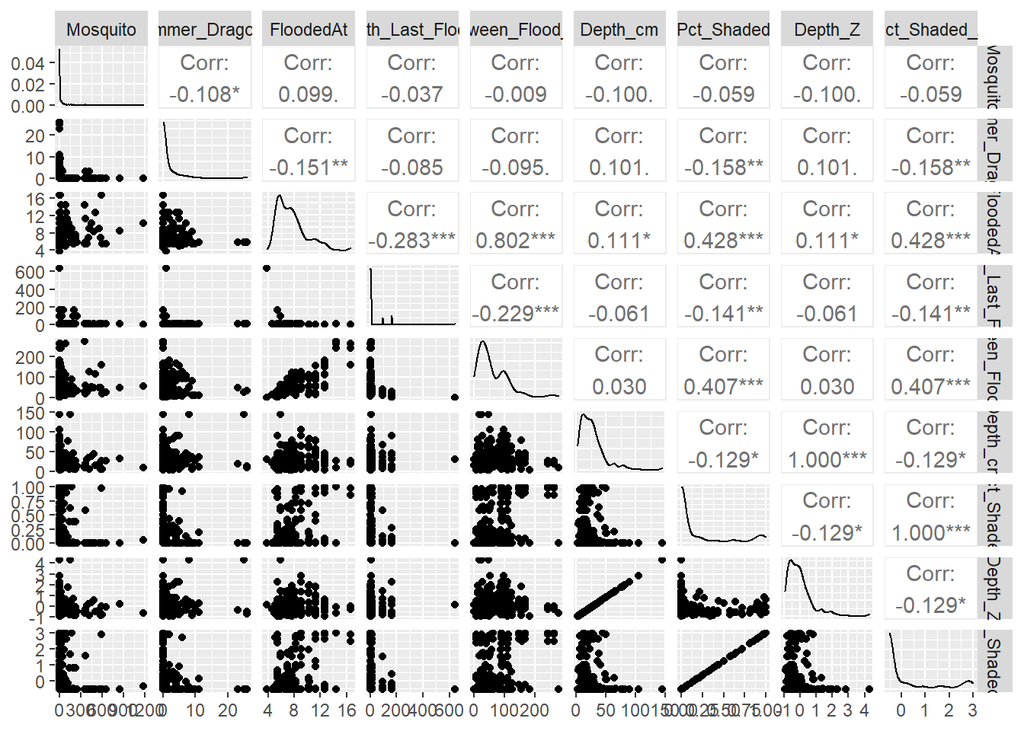

## Model Family

### Standard Poisson GLMM

```
##  Family: poisson  ( log )
## Formula:          Mosquito ~ Skimmer_Z * Temp_Zscore + (1 | Pool_ID)
## Data: abundance.df
##
##      AIC      BIC   logLik deviance df.resid
##  10030.7  10050.0  -5010.4  10020.7      347
##
## Random effects:
##
## Conditional model:
##  Groups  Name        Variance Std.Dev.
##  Pool_ID (Intercept) 11.56    3.399
## Number of obs: 352, groups:  Pool_ID, 229
##
## Conditional model:
##                       Estimate Std. Error z value Pr(>|z|)
## (Intercept)            0.10255    0.27843   0.368   0.7126
## Skimmer_Z             -2.13837    0.08656 -24.704   <2e-16 ***
## Temp_Zscore            0.66556    0.27499   2.420   0.0155 *
## Skimmer_Z:Temp_Zscore  0.83149    0.05725  14.523   <2e-16 ***
## ---
## Signif. codes:  0 '***' 0.001 '**' 0.01 '*' 0.05 '.' 0.1 ' ' 1
```

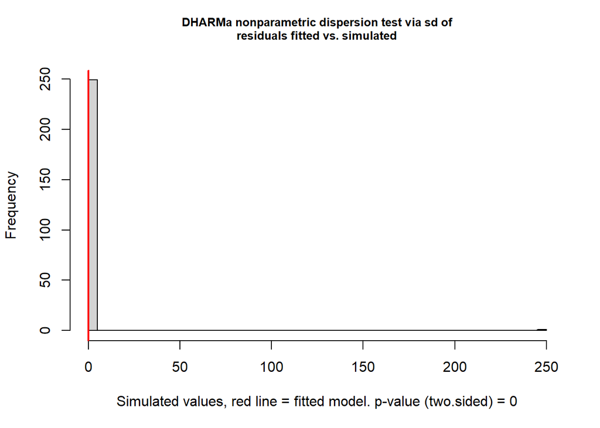

```
##
##  DHARMa nonparametric dispersion test via sd of residuals fitted vs.
##  simulated
##
## data:  simulationOutput
## dispersion = 1.1885e-07, p-value < 2.2e-16
## alternative hypothesis: two.sided
```

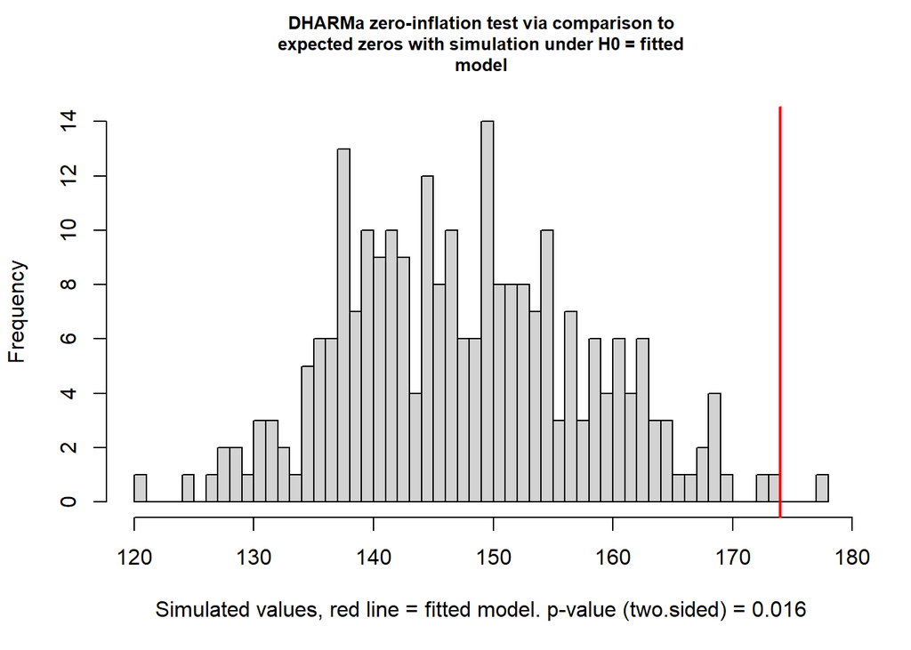

```
##
##  DHARMa zero-inflation test via comparison to expected zeros with
##  simulation under H0 = fitted model
##
## data:  simulationOutput
## ratioObsSim = 1.1748, p-value = 0.016
## alternative hypothesis: two.sided
```

### Negative Binomial GLMM

```
##  Family: nbinom2  ( log )
## Formula:          Mosquito ~ Skimmer_Z * Temp_Zscore + (1 | Pool_ID)
## Data: abundance.df
##
##      AIC      BIC   logLik deviance df.resid
##   2233.9   2257.1  -1111.0   2221.9      346
##
## Random effects:
##
## Conditional model:
##  Groups  Name        Variance Std.Dev.
##  Pool_ID (Intercept) 4.34e-08 0.0002083
## Number of obs: 352, groups:  Pool_ID, 229
##
## Dispersion parameter for nbinom2 family (): 0.131
##
## Conditional model:
##                       Estimate Std. Error z value Pr(>|z|)
## (Intercept)             3.5136     0.1595  22.024  < 2e-16 ***
## Skimmer_Z              -1.2310     0.2367  -5.200 1.99e-07 ***
## Temp_Zscore             0.5400     0.1463   3.691 0.000224 ***
## Skimmer_Z:Temp_Zscore   0.2548     0.2039   1.250 0.211443
## ---
## Signif. codes:  0 '***' 0.001 '**' 0.01 '*' 0.05 '.' 0.1 ' ' 1
```

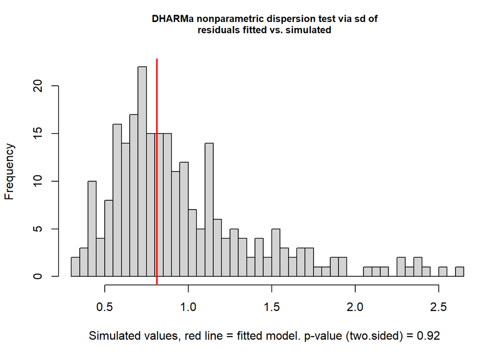

```
##
##  DHARMa nonparametric dispersion test via sd of residuals fitted vs.
##  simulated
##
## data:  simulationOutput
## dispersion = 0.83814, p-value = 0.92
## alternative hypothesis: two.sided
```

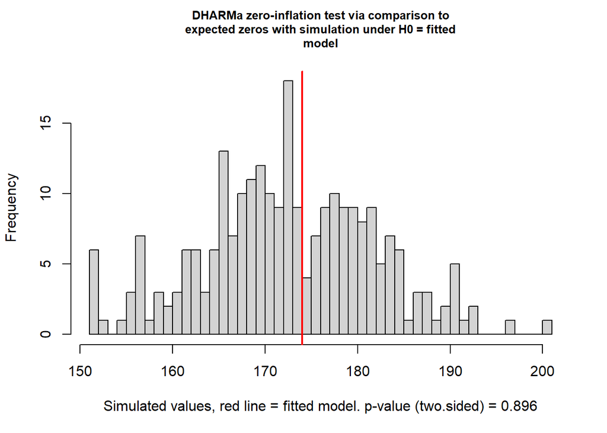

```
##
##  DHARMa zero-inflation test via comparison to expected zeros with
##  simulation under H0 = fitted model
##
## data:  simulationOutput
## ratioObsSim = 1.0059, p-value = 0.896
## alternative hypothesis: two.sided
```

### Zero-Inflated Poisson GLMM

```
##  Family: truncated_poisson  ( log )
## Formula:          Mosquito ~ Skimmer_Z * Temp_Zscore + (1 | Pool_ID)
## Zero inflation:            ~.
## Data: abundance.df
##
##      AIC      BIC   logLik deviance df.resid
##   6001.3   6039.9  -2990.6   5981.3      342
##
## Random effects:
##
## Conditional model:
##  Groups  Name        Variance Std.Dev.
##  Pool_ID (Intercept) 3.798    1.949
## Number of obs: 352, groups:  Pool_ID, 229
##
## Zero-inflation model:
##  Groups  Name        Variance Std.Dev.
##  Pool_ID (Intercept) 0.8117   0.9009
## Number of obs: 352, groups:  Pool_ID, 229
##
## Conditional model:
##                       Estimate Std. Error z value Pr(>|z|)
## (Intercept)             2.5030     0.1812  13.813  < 2e-16 ***
## Skimmer_Z              -2.0984     0.1543 -13.604  < 2e-16 ***
## Temp_Zscore             1.1727     0.1971   5.949 2.69e-09 ***
## Skimmer_Z:Temp_Zscore   2.3525     0.2286  10.291  < 2e-16 ***
## ---
## Signif. codes:  0 '***' 0.001 '**' 0.01 '*' 0.05 '.' 0.1 ' ' 1
##
## Zero-inflation model:
##                       Estimate Std. Error z value Pr(>|z|)
## (Intercept)            -0.0164     0.1401  -0.117  0.90680
## Skimmer_Z               0.6014     0.2036   2.954  0.00314 **
## Temp_Zscore            -0.1668     0.1488  -1.121  0.26231
## Skimmer_Z:Temp_Zscore  -0.1212     0.1663  -0.729  0.46611
## ---
## Signif. codes:  0 '***' 0.001 '**' 0.01 '*' 0.05 '.' 0.1 ' ' 1
```

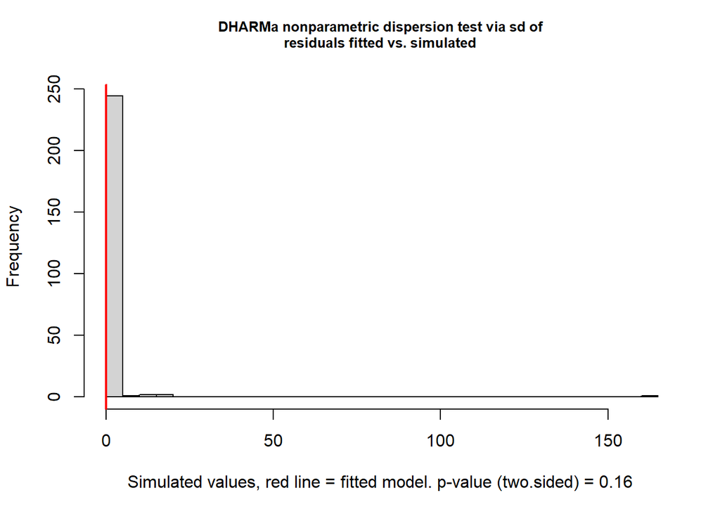

```
##
##  DHARMa nonparametric dispersion test via sd of residuals fitted vs.
##  simulated
##
## data:  simulationOutput
## dispersion = 0.0013544, p-value = 0.16
## alternative hypothesis: two.sided
```

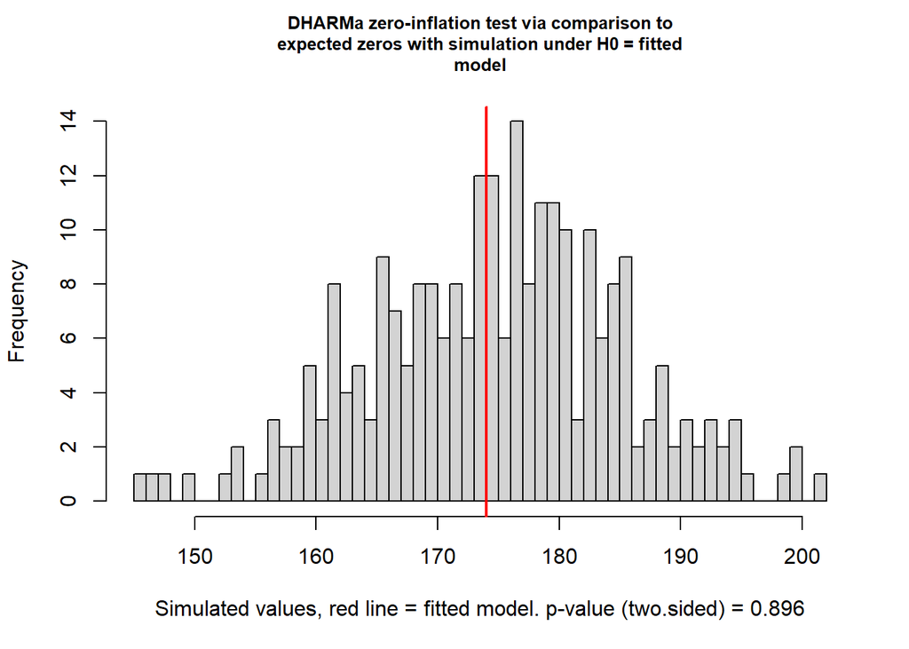

```
##
##  DHARMa zero-inflation test via comparison to expected zeros with
##  simulation under H0 = fitted model
##
## data:  simulationOutput
## ratioObsSim = 0.99267, p-value = 0.896
## alternative hypothesis: two.sided
```

### Zero-Inflated Negative Binomial GLMM

```
##  Family: truncated_nbinom2  ( log )
## Formula:          Mosquito ~ Skimmer_Z * Temp_Zscore + (1 | Pool_ID)
## Zero inflation:            ~.
## Data: abundance.df
##
##      AIC      BIC   logLik deviance df.resid
##   2222.6   2265.1  -1100.3   2200.6      341
##
## Random effects:
##
## Conditional model:
##  Groups  Name        Variance  Std.Dev.
##  Pool_ID (Intercept) 2.216e-08 0.0001489
## Number of obs: 352, groups:  Pool_ID, 229
##
## Zero-inflation model:
##  Groups  Name        Variance Std.Dev.
##  Pool_ID (Intercept) 0.8116   0.9009
## Number of obs: 352, groups:  Pool_ID, 229
##
## Dispersion parameter for truncated_nbinom2 family (): 0.159
##
## Conditional model:
##                       Estimate Std. Error z value Pr(>|z|)
## (Intercept)             2.6705     0.3451   7.739 9.98e-15 ***
## Skimmer_Z              -4.0367     0.6881  -5.867 4.45e-09 ***
## Temp_Zscore             2.0368     0.4147   4.912 9.03e-07 ***
## Skimmer_Z:Temp_Zscore   4.3698     1.1351   3.850 0.000118 ***
## ---
## Signif. codes:  0 '***' 0.001 '**' 0.01 '*' 0.05 '.' 0.1 ' ' 1
##
## Zero-inflation model:
##                       Estimate Std. Error z value Pr(>|z|)
## (Intercept)           -0.01639    0.14011  -0.117  0.90685
## Skimmer_Z              0.60133    0.20358   2.954  0.00314 **
## Temp_Zscore           -0.16677    0.14880  -1.121  0.26237
## Skimmer_Z:Temp_Zscore -0.12119    0.16627  -0.729  0.46610
## ---
## Signif. codes:  0 '***' 0.001 '**' 0.01 '*' 0.05 '.' 0.1 ' ' 1
```

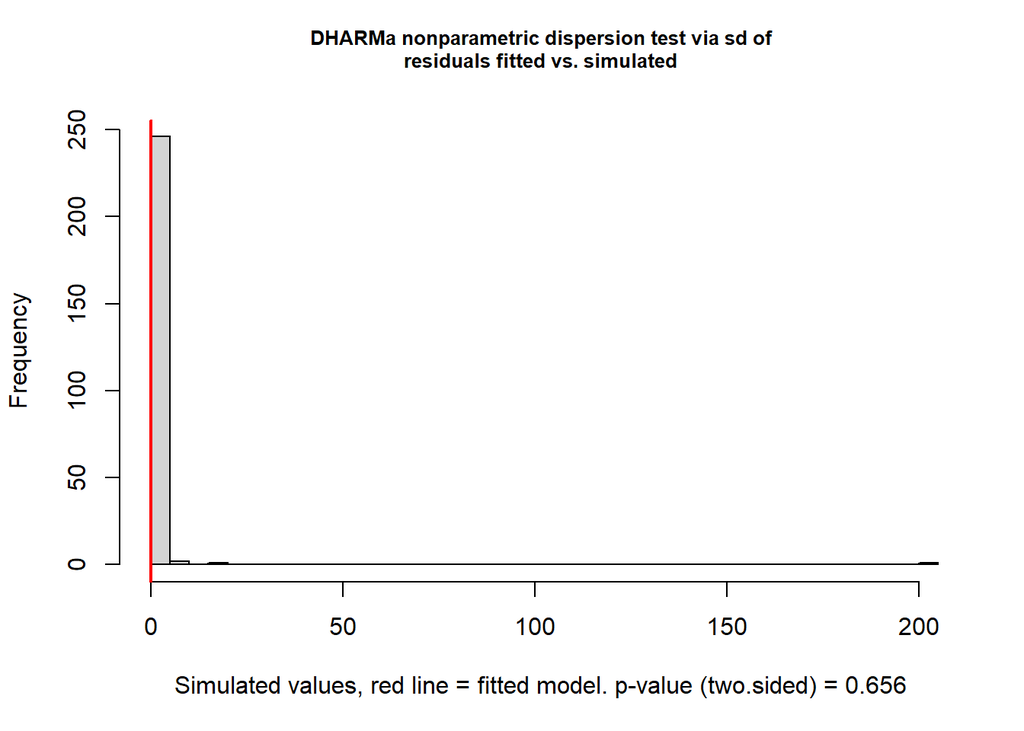

```
##
##  DHARMa nonparametric dispersion test via sd of residuals fitted vs.
##  simulated
##
## data:  simulationOutput
## dispersion = 0.0047967, p-value = 0.656
## alternative hypothesis: two.sided
```

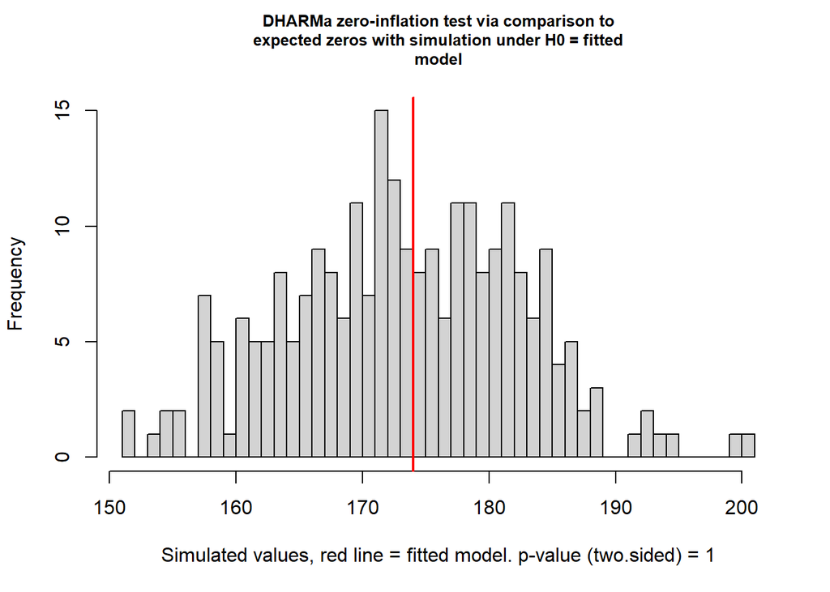

```
##
##  DHARMa zero-inflation test via comparison to expected zeros with
##  simulation under H0 = fitted model
##
## data:  simulationOutput
## ratioObsSim = 1.0012, p-value = 1
## alternative hypothesis: two.sided
```

The truncated negative binomial model seems to work the best (lowest AIC), and indicates a positive effect of temperature on mosquito abundance, a negative effect of dragonflies, and a positive interaction term. This suggests that mosquitoes are more abundant in warmer pools, less abundant where dragonflies are present, but temperature may mitigate this effect somewhat.

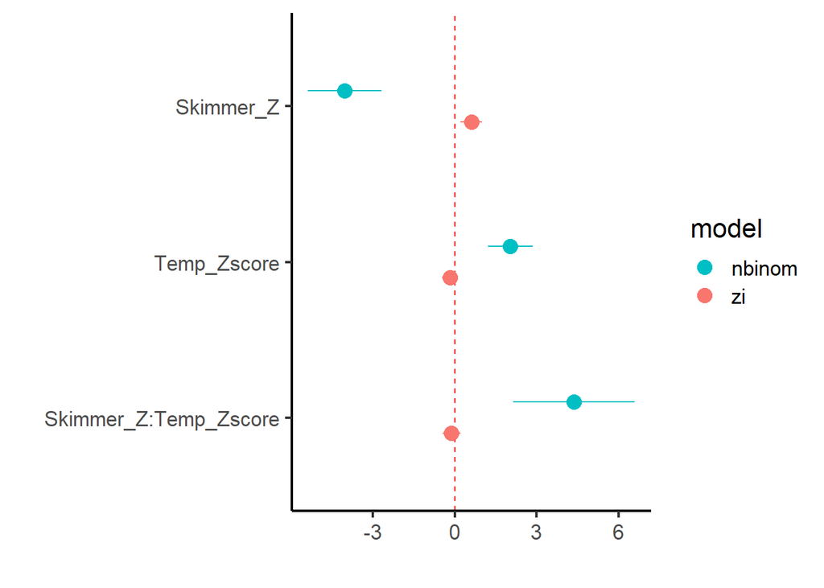

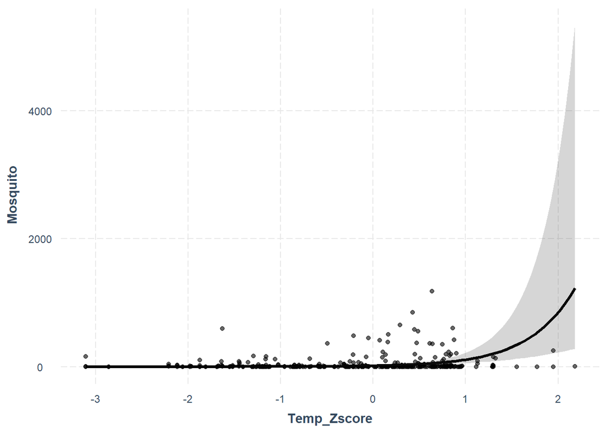

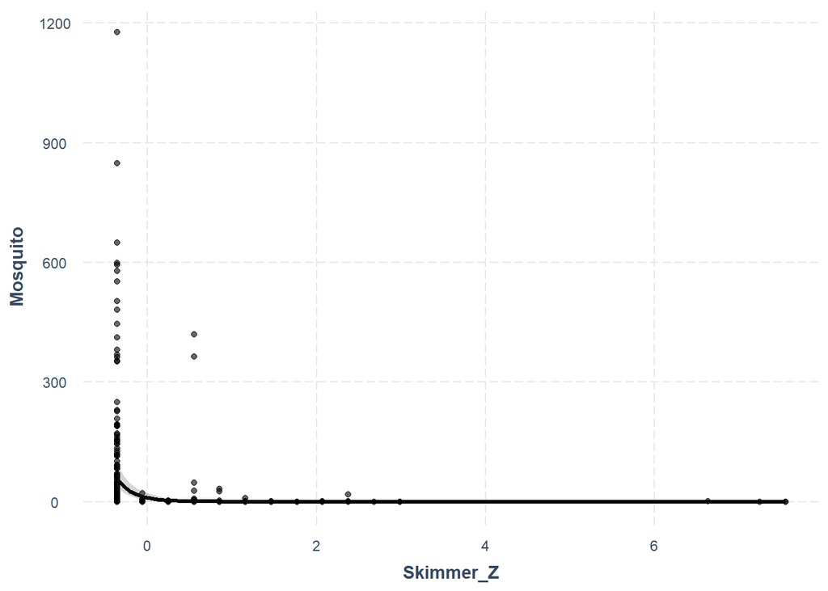

```
## Saving 178 x 127 mm image
```

Note: a temperature Z score of 1 means that the pool reaches a daily maximum temperature of around 34$^\circ$C, and the mean number of skimmers (i.e., Z = 0) was a little over 1.

## Models Including Flooding and Other Variables

```
##  Family: truncated_nbinom2  ( log )
## Formula:
## Mosquito ~ Skimmer_Z * Temp_Zscore + Days_Between_Z + (1 | Pool_ID)
## Zero inflation:            ~.
## Data: abundance.df
##
##      AIC      BIC   logLik deviance df.resid
##   2226.5   2276.8  -1100.3   2200.5      339
##
## Random effects:
##
## Conditional model:
##  Groups  Name        Variance  Std.Dev.
##  Pool_ID (Intercept) 2.947e-08 0.0001717
## Number of obs: 352, groups:  Pool_ID, 229
##
## Zero-inflation model:
##  Groups  Name        Variance Std.Dev.
##  Pool_ID (Intercept) 0.8148   0.9027
## Number of obs: 352, groups:  Pool_ID, 229
##
## Dispersion parameter for truncated_nbinom2 family (): 0.159
##
## Conditional model:
##                       Estimate Std. Error z value Pr(>|z|)
## (Intercept)            2.66940    0.34590   7.717 1.19e-14 ***
## Skimmer_Z             -4.04323    0.69130  -5.849 4.95e-09 ***
## Temp_Zscore            2.05273    0.42516   4.828 1.38e-06 ***
## Days_Between_Z         0.03581    0.14955   0.239 0.810737
## Skimmer_Z:Temp_Zscore  4.38216    1.15035   3.809 0.000139 ***
## ---
## Signif. codes:  0 '***' 0.001 '**' 0.01 '*' 0.05 '.' 0.1 ' ' 1
##
## Zero-inflation model:
##                        Estimate Std. Error z value Pr(>|z|)
## (Intercept)           -0.016074   0.140450  -0.114  0.90888
## Skimmer_Z              0.601681   0.203826   2.952  0.00316 **
## Temp_Zscore           -0.165375   0.153422  -1.078  0.28107
## Days_Between_Z         0.005335   0.141521   0.038  0.96993
## Skimmer_Z:Temp_Zscore -0.121283   0.166277  -0.729  0.46575
## ---
## Signif. codes:  0 '***' 0.001 '**' 0.01 '*' 0.05 '.' 0.1 ' ' 1
```

Including days since last flood doesn’t improve the overall AIC, and doesn’t shake out as a significant term.

```
##  Family: truncated_nbinom2  ( log )
## Formula:
## Mosquito ~ Skimmer_Z * Temp_Zscore + FloodedAt_Z + Days_Between_Z +
##     (1 | Pool_ID)
## Zero inflation:            ~.
## Data: abundance.df
##
##      AIC      BIC   logLik deviance df.resid
##   2214.2   2272.2  -1092.1   2184.2      337
##
## Random effects:
##
## Conditional model:
##  Groups  Name        Variance  Std.Dev.
##  Pool_ID (Intercept) 2.784e-08 0.0001669
## Number of obs: 352, groups:  Pool_ID, 229
##
## Zero-inflation model:
##  Groups  Name        Variance Std.Dev.
##  Pool_ID (Intercept) 0.9555   0.9775
## Number of obs: 352, groups:  Pool_ID, 229
##
## Dispersion parameter for truncated_nbinom2 family (): 0.179
##
## Conditional model:
##                       Estimate Std. Error z value Pr(>|z|)
## (Intercept)             2.6938     0.3189   8.448  < 2e-16 ***
## Skimmer_Z              -3.7796     0.6625  -5.705 1.16e-08 ***
## Temp_Zscore             2.0814     0.4017   5.181 2.21e-07 ***
## FloodedAt_Z             0.5134     0.2401   2.138   0.0325 *
## Days_Between_Z         -0.4062     0.2284  -1.778   0.0754 .
## Skimmer_Z:Temp_Zscore   4.2920     1.0952   3.919 8.90e-05 ***
## ---
## Signif. codes:  0 '***' 0.001 '**' 0.01 '*' 0.05 '.' 0.1 ' ' 1
##
## Zero-inflation model:
##                       Estimate Std. Error z value Pr(>|z|)
## (Intercept)           -0.05381    0.14592  -0.369  0.71232
## Skimmer_Z              0.52696    0.20145   2.616  0.00890 **
## Temp_Zscore           -0.28663    0.16656  -1.721  0.08528 .
## FloodedAt_Z           -0.81561    0.26624  -3.063  0.00219 **
## Days_Between_Z         0.59416    0.24299   2.445  0.01447 *
## Skimmer_Z:Temp_Zscore -0.06215    0.16425  -0.378  0.70515
## ---
## Signif. codes:  0 '***' 0.001 '**' 0.01 '*' 0.05 '.' 0.1 ' ' 1
```

This needs some playing with for model selection.

```
##
## Model selection based on AICc:
##
##        K    AICc Delta_AICc AICcWt Cum.Wt       LL
## mod 4 11 2216.92       0.00   0.82   0.82 -1097.07
## mod 7 13 2219.98       3.06   0.18   1.00 -1096.45
## mod 2  7 2231.28      14.36   0.00   1.00 -1108.48
## mod 6  9 2234.98      18.06   0.00   1.00 -1108.23
## mod 1  7 2239.18      22.26   0.00   1.00 -1112.43
## mod 5  9 2240.84      23.91   0.00   1.00 -1111.16
## mod 3  7 2245.38      28.46   0.00   1.00 -1115.53
```

```
##  Family: truncated_nbinom2  ( log )
## Formula:          Mosquito ~ Temp_Zscore * Skimmer_Z + (1 | Date)
## Zero inflation:            ~.
## Data: abundance.df
##
##      AIC      BIC   logLik deviance df.resid
##   2216.1   2258.6  -1097.1   2194.1      341
##
## Random effects:
##
## Conditional model:
##  Groups Name        Variance Std.Dev.
##  Date   (Intercept) 0.09772  0.3126
## Number of obs: 352, groups:  Date, 21
##
## Zero-inflation model:
##  Groups Name        Variance Std.Dev.
##  Date   (Intercept) 0.4333   0.6583
## Number of obs: 352, groups:  Date, 21
##
## Dispersion parameter for truncated_nbinom2 family (): 0.174
##
## Conditional model:
##                       Estimate Std. Error z value Pr(>|z|)
## (Intercept)             2.7648     0.3728   7.417 1.20e-13 ***
## Temp_Zscore             1.9470     0.4412   4.413 1.02e-05 ***
## Skimmer_Z              -3.8394     0.7647  -5.021 5.14e-07 ***
## Temp_Zscore:Skimmer_Z   4.0640     1.2413   3.274  0.00106 **
## ---
## Signif. codes:  0 '***' 0.001 '**' 0.01 '*' 0.05 '.' 0.1 ' ' 1
##
## Zero-inflation model:
##                       Estimate Std. Error z value Pr(>|z|)
## (Intercept)           -0.10835    0.20518  -0.528   0.5974
## Temp_Zscore           -0.19450    0.13335  -1.459   0.1447
## Skimmer_Z              0.41628    0.18528   2.247   0.0247 *
## Temp_Zscore:Skimmer_Z -0.09756    0.15976  -0.611   0.5414
## ---
## Signif. codes:  0 '***' 0.001 '**' 0.01 '*' 0.05 '.' 0.1 ' ' 1
```

Model 4, which includes skimmers and temperature only, wins. This one suggests that mosquitoes are less likely to be present when dragonflies are abundant, and when they are present, they’re more abundant with fewer dragonflies, warmer temperatures, or in warm pools that have dragonflies.

Running this with flood height instead of time since last flood doesn’t change the outcome much.

```
## # R2 for Mixed Models
##
##   Conditional R2: 0.966
##      Marginal R2: 0.964
```

```
## Saving 178 x 127 mm image
## Saving 178 x 127 mm image
## Saving 178 x 127 mm image
## Saving 178 x 127 mm image
```